# Campus Placement Analysis for Jain University

#### 0.2.2.4 Did students with work experience receive higher salary?

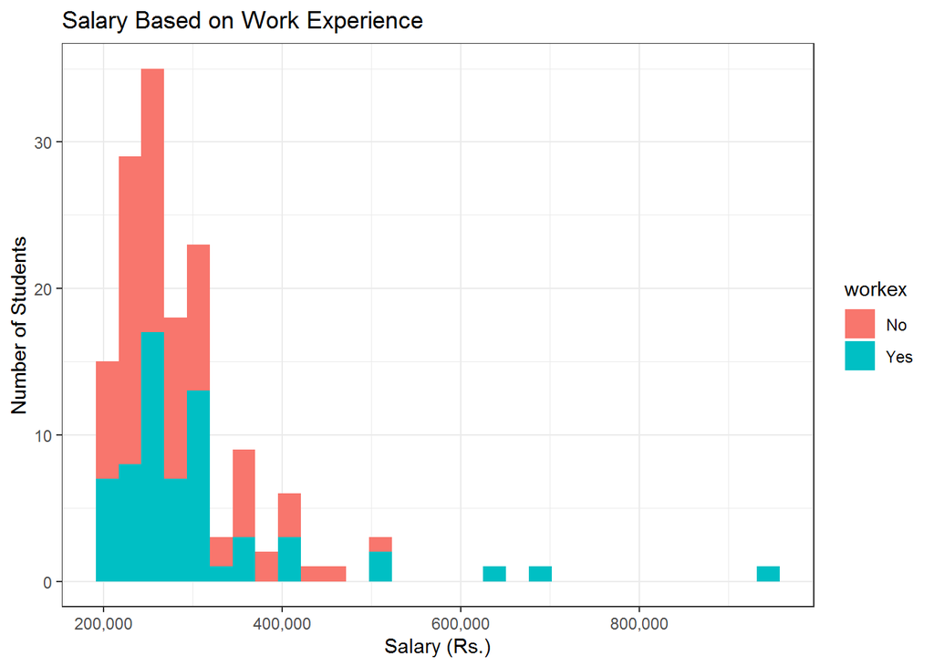

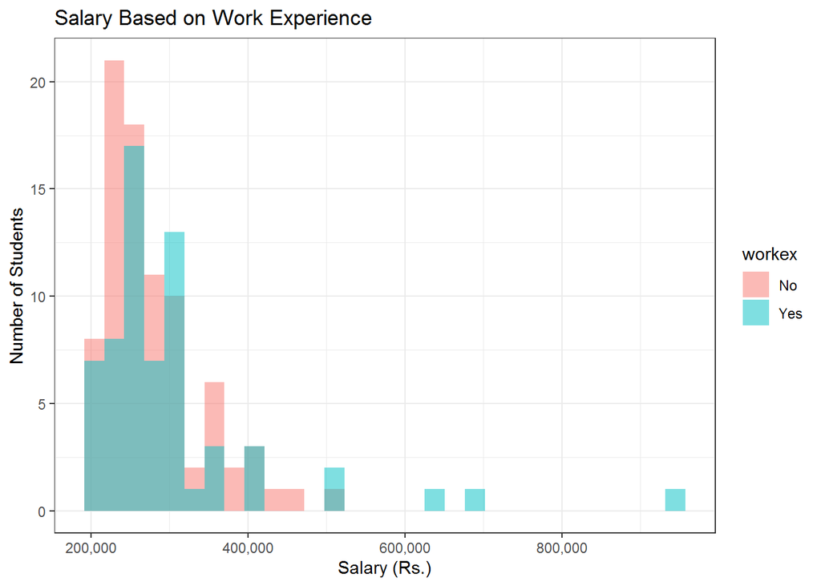

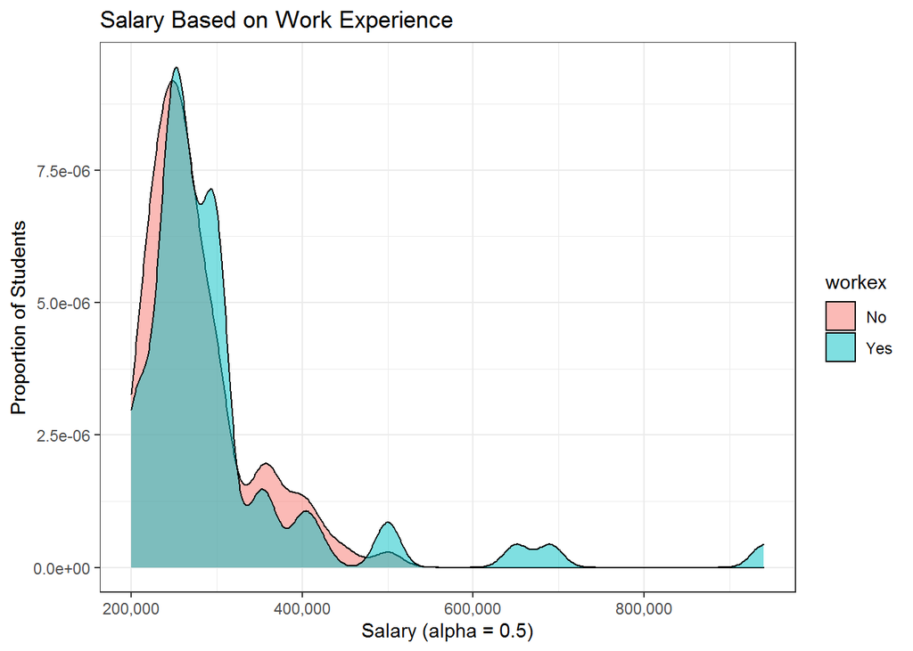

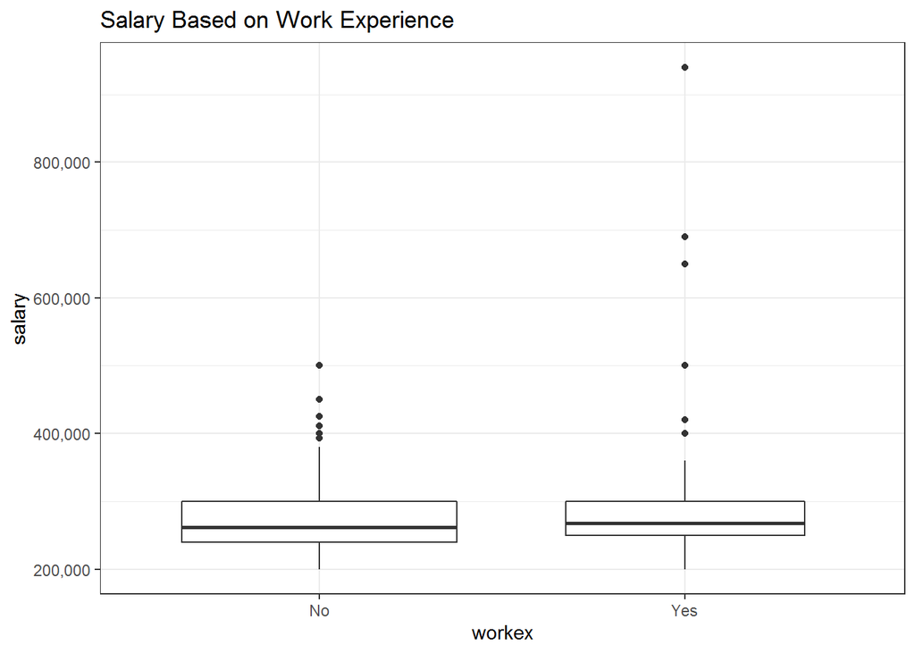

**Remark:** From the density plot we see that a similar proportion of stduents with and without work experience received salaries between Rs.200,000 - Rs.450,000. However, those in the salaries in the range of Rs.600,000 - Rs.800,000 were exclusively offered to those with work experience.

Note that when we compare this density plot with that from comparison of salary based on MBA specialization (remark for salary vs specialization), we see that the students in the higher salary range are excluseively from Mkt&Fin.

Upon comparison with the graph for salary and gender (remark for salary vs gender), we see that both male and female students belong to that salary bracket.

#### 0.2.2.5 Did the undergraduate degree stream influence the salary offered?

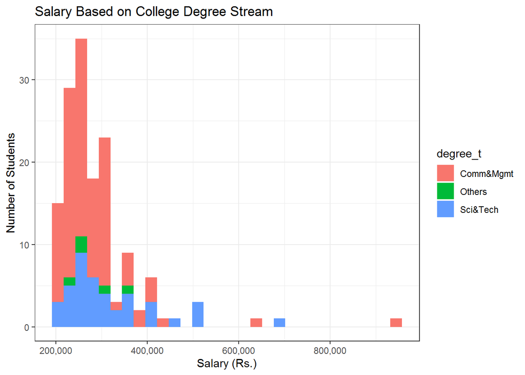

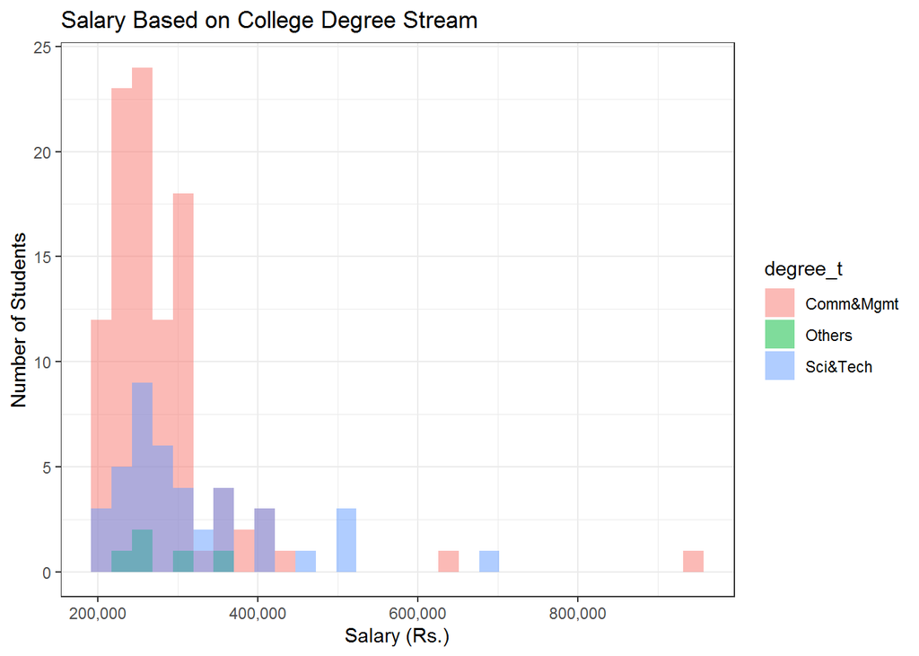

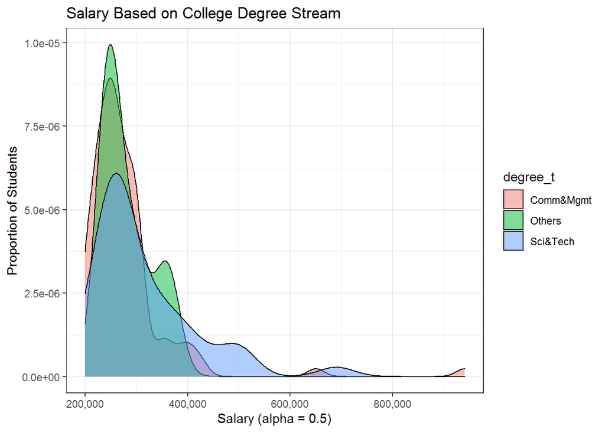

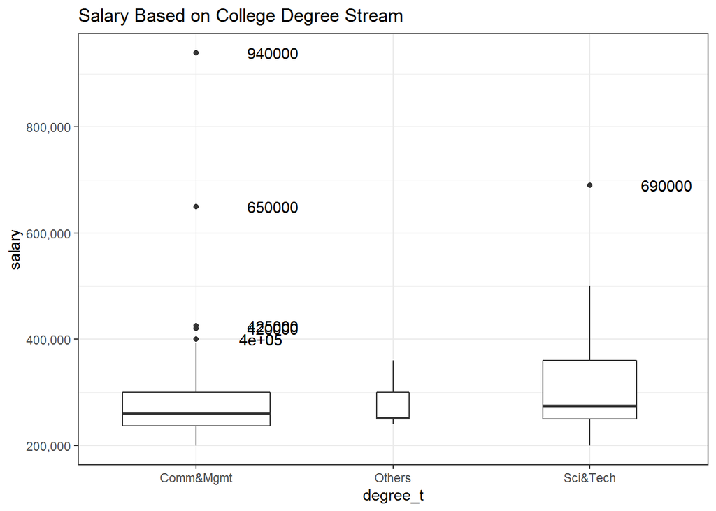

**Remark:** Sci&Tech and Comm&Mgmt students received highest salaries. For all three streams the salary distributions are skewed to the right. Salaries above Rs.400,000 went to Sci&Tech and Comm&Mgmt students only, with the latter group receiving a larger number of salaries beyong the fourth quartile.

#### 0.2.2.6 Did the salary depend on the MBA test score? How did work experience influence it?

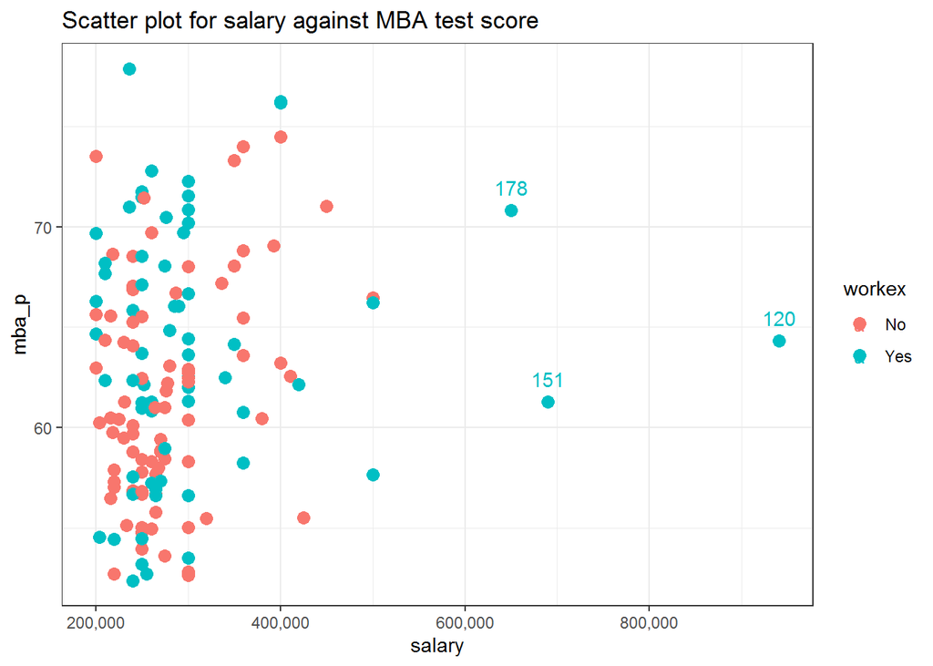

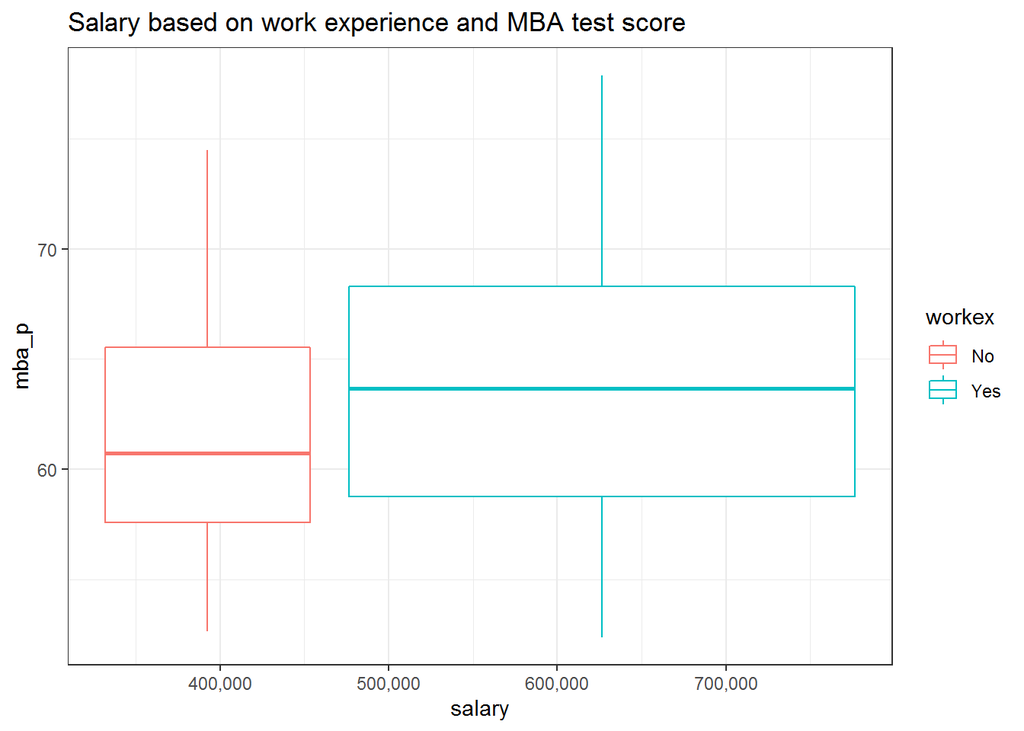

**Remark:** From the scatter plot we see that regardless of the MBA test score, only students with work experience were offered salaries in the extremely high range. This implies that other factors are likely to have influenced this decision.

#### 0.2.2.7 Did the salary depend on the employment test score? How did work experience influence it?

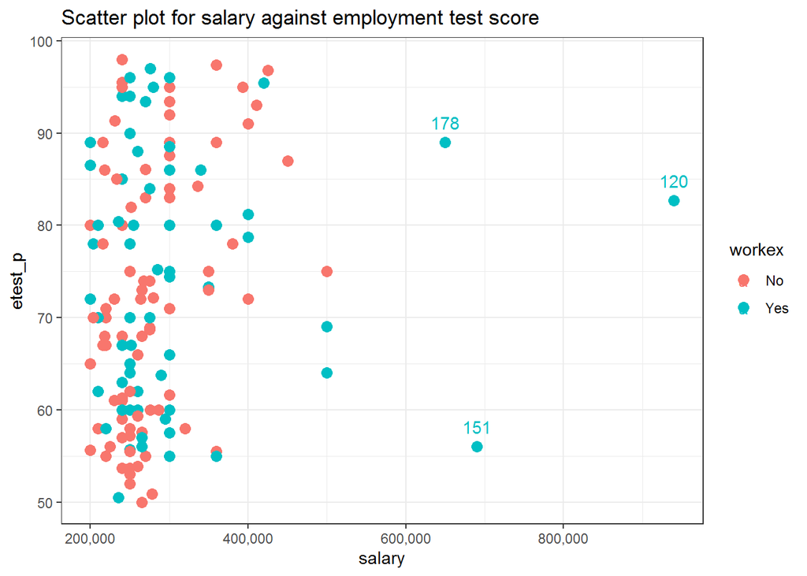

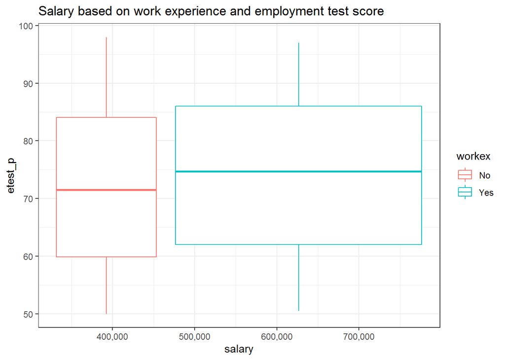

**Remark:** The scatter plot shows that the highest salaries were offered only to students who had work experience regardless of their empployment test score. This implies other factors are likely to have influenced this decision.

#### 0.2.2.8 Did the salary depend on the undergraduate degree test score? How did work experience influence it?

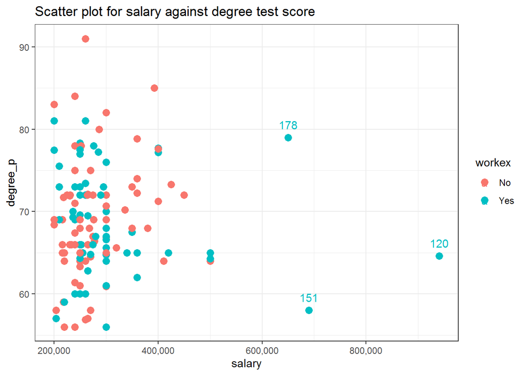

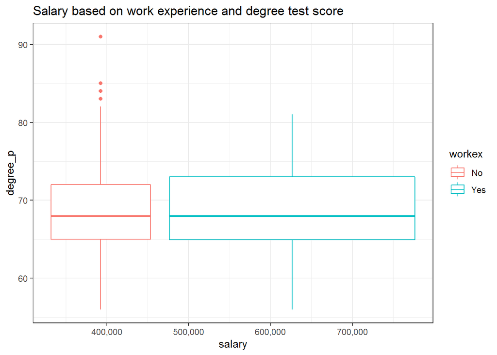

**Remark:** The scatter plot on the left shows for salaries less than Rs.500,000 an even distribution of salaries between students with and without work experience. Salaries larger than Rs.500,000 were offered specifically to students with work experience, regardless of their degree test score. It is reasonable to suggest that other factors have influenced this decision.

#### 0.2.2.9 Did the salary depend on the higher secondary test score? How did work experience influence it?

[figure not shown]

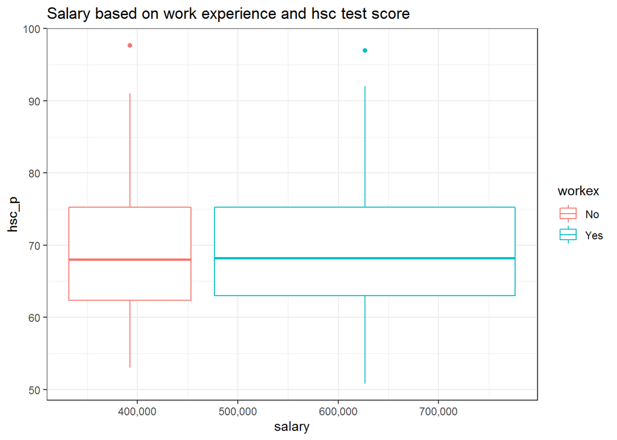

**Remark:** The scatter plot on the left shows for salaries less than Rs.500,000 an even distribution of salaries between students with and without work experience. Salaries larger than Rs.500,000 were offered specifically to students with work experience, regardless of their higher secondary test score. It is reasonable to suggest that other factors have influenced this decision.

#### 0.2.2.10 Did the salary depend on the secondary test score? How did work experience influence it?

[figure not shown]

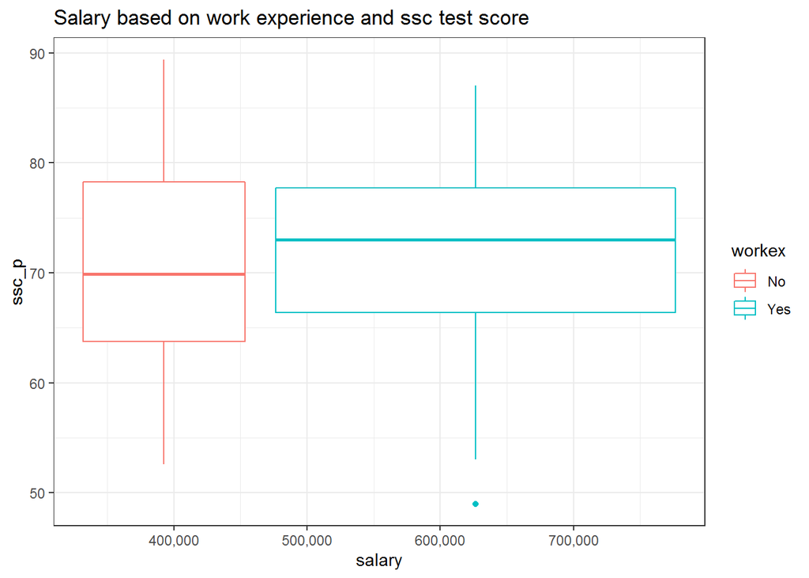

**Remark:** The scatter plot on the left shows for salaries less than Rs.500,000 an even distribution of salaries between students with and without work experience. Salaries larger than Rs.500,000 were offered specifically to students with work experience, regardless of their secondary test score. It is reasonable to suggest that other factors have influenced this decision.

*For the last five inspection of salary with respect to the five test scores we can see that there were always three students with work experience that received salaries above Rs.600,000. The following table shows the observations related to these three students.*

```r
highsal <- knitr::kable(placed %>%
               filter(salary > 600000))
highsal
```

| sl_no | gender | ssc_p | ssc_b | hsc_p | hsc_b | hsc_s | degree_p | degree_t | workex | etest_p | specialisation | mba_p | status | salary |
| --- | --- | --- | --- | --- | --- | --- | --- | --- | --- | --- | --- | --- | --- | --- |
| 120 | M | 60.8 | Central | 68.40 | Central | Commerce | 64.6 | Comm&Mgmt | Yes | 82.66 | Mkt&Fin | 64.34 | Placed | 940000 |
| 151 | M | 71.0 | Central | 58.66 | Central | Science | 58.0 | Sci&Tech | Yes | 56.00 | Mkt&Fin | 61.30 | Placed | 690000 |
| 178 | F | 73.0 | Central | 97.00 | Others | Commerce | 79.0 | Comm&Mgmt | Yes | 89.00 | Mkt&Fin | 70.81 | Placed | 650000 |

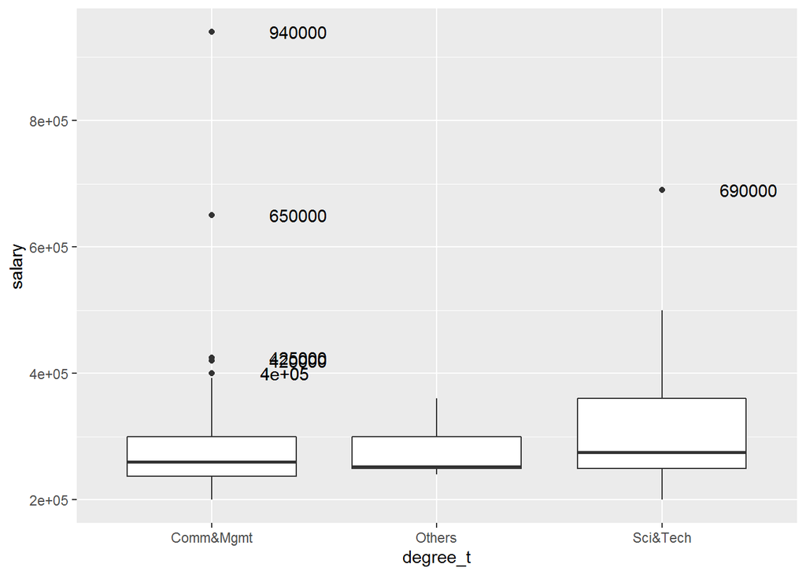

```r
ggplot(placed, aes(x = degree_t, y = salary)) +
  geom_boxplot() +
  stat_summary(
    aes(label = round(stat(y), 1)),
    geom = "text",
    fun.y = function(y) { o <- boxplot.stats(y)$out; if(length(o) == 0) NA else o },
    hjust = -1
  )
```